# dtplyr 鬼はええ！ このままdplyrパイプライン 全部data.tableで計算しようぜ！

2022-07-23 第100回R勉強会@東京  
@eitsupi

# はじめに

## 自己紹介

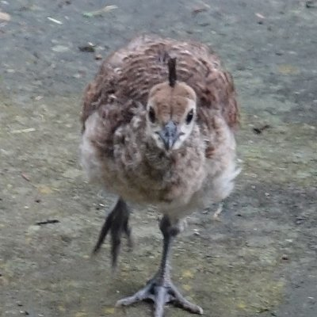

- [@eitsupi](https://twitter.com/eitsupi)
- 製造業勤務
  - Excelが嫌になりRを触り初めて3年
- Dockerイメージ`rocker/r-ver`他のメンテナー

# [前回](https://eitsupi.github.io/tokyorslide/tokyor_97/)のあらすじ

巨大なデータを扱うときにはCSVではなくParquetを使うと便利です。

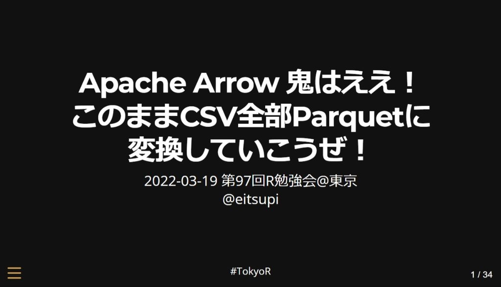

## 今日の話

- `dplyr`バックエンドの速度比較をやってみた。
- `dtplyr`の日本語の情報が少ないので共有したい。
  - [今こそ、data.tableを学ぼう！](https://speakerdeck.com/s_uryu/datatable1130)(2020-08-01)もご確認ください。

### 対象かも

- ✅`dplyr`派
- ✅`dbplyr`や`dtplyr`を試す機会のなかった方

### 対象外かも

- ✅`data.table`派

# 結論

Q. `data.table`って速いの？

A. `dtplyr`ですぐに試せるのでやってみましょう！  
（`tidyverse`パッケージインストール時にインストールされてます！）

# `dtplyr`, `arrow`, `duckdb`

## `dplyr`バックエンド達

`dplyr`で記述したデータ操作を`dplyr`外で実行するパッケージ。

- tydyverse[^1]
  - [`multidplyr`](https://multidplyr.tidyverse.org/) : Rの計算を分散
  - [`dtplyr`](https://dtplyr.tidyverse.org/) : [`data.table`](https://rdatatable.gitlab.io/data.table/)のクエリに変換して計算実行
  - [`dbplyr`](https://dbplyr.tidyverse.org/) : [`duckdb`](https://duckdb.org/docs/api/r)などのDBにSQLを送信して計算実行
- その他
  - [`sparklyr`](https://spark.rstudio.com/) : SparkにSQLを送信して計算実行
  - [`arrow`](https://arrow.apache.org/docs/r/) : Arrow C++ライブラリの計算エンジンAceroで計算実行

## どれが速いか気になる！

- `dtplyr`, `arrow`, `dbplyr`+`duckdb`は同じような目的（ローカル実行で集約計算などを速くしたい）で使用されます。
  - [前回の発表](https://eitsupi.github.io/tokyorslide/tokyor_97/)で`arrow`と共に`duckdb`を紹介したところ、  
    「`duckdb`の使いどころが分からない」との感想をいただいた。
- 有名な[H2Oベンチマーク](https://h2oai.github.io/db-benchmark/)は最後の実行が2021年7月、 まだ`arrow`は`dplyr::summarise`を実行できなかった頃の結果。

# ベンチマーク

## 対象パッケージ

```r
library(dplyr)
library(dtplyr)
library(arrow)
library(duckdb)
```

#TokyoR

## 脚注

[^1]: [dplyr backends: multidplyr 0.1.0, dtplyr 1.1.0, dbplyr 2.1.0](https://www.tidyverse.org/blog/2021/02/dplyr-backends/)